# Project: Investigate European Soccer Data

This report has been created as a part of the [Data Analyst Nanodegree Program](https://classroom.udacity.com/nanodegrees/nd002) on Udacity.

## Introduction

Popularity of soccer leagues in Europe is growing everyday. The big five European leagues (England, Spain, Germany, Italy and France) generated a record cummulative revenue of 15 billion Euro revenue during the 2017/18 season. This amounts to a staggering 6% increase from the previous years revenue.

The European Soccer dataset that I choose for this project has been provided by Kaggle. This dataset is quite extensive. It contains data for soccer matches, players, and teams from several European countries from 2008 to 2016.

1. It would be interesting to see which countries hosted the more league matches from 2008 to 2016?
2. Which player had the most penalties among all leagues from 2008 to 2016 ?

To address above questions we choose to use Python as our data analysis tool.

## SQLite3 Database

Firstly, we need to pull the soccer data by interacting with the SQLite3 database. To do so, we import the **sqlite3** module, create a SQL connection and execute SQL queries of choice.

```python
import pandas as pd
import sqlite3
import matplotlib.pyplot as plt
import numpy as np
import seaborn as sns
import folium
%matplotlib inline
```

```python
#
# Function to create an SQL connection
def sql_connection(loc):
    try:
        con = sqlite3.connect(loc)
        print("Connection successfully established to Database: {}\n".format(loc))
        return con
    except Error:
        print(Error)

#
# Function to return a list of tables present in the SQLite3 Database
def sql_tables(con):
    cursorObj = con.cursor()
    cursorObj.execute('SELECT name from sqlite_master where type="table"')
    list_tables = list(itab[0] for itab in cursorObj.fetchall())
    return list_tables

#
# Function to return rows from Player_Atrributes table in the SQLite3 Database
def sql_table(con,table_name):
    df = pd.read_sql_query("SELECT * FROM "+table_name, con)
    return df


# Call functions to load soccer data from SQLite database
con = sql_connection("../datasets/europe_soccer.sqlite")
tab = sql_tables(con)
print('List of Tables in the Soccer Database are:')
for itab in tab:
    print(itab)
#
# Database tables are loaded into Pandas DataFrames
df_pa = sql_table(con, 'Player_Attributes')
df_p  = sql_table(con, 'Player')
df_m  = sql_table(con, 'Match')
df_l  = sql_table(con, 'League')
df_c  = sql_table(con, 'Country')
df_t  = sql_table(con, 'Team')
df_ta = sql_table(con, 'Team_Attributes')
```

```
Connection successfully established to Database: ../datasets/europe_soccer.sqlite

List of Tables in the Soccer Database are:
sqlite_sequence
Player_Attributes
Player
Match
League
Country
Team
Team_Attributes
```

## Data Wrangling

In this section, we are going to assess and clean the data that is required to answer the 2 questions posted above. Of the different data tables present, we only need `Match`, `League`, `Player`, and `Player Atributes` tables to answer the questions.

`Matches` and `Country` tables are already loaded as `df_m` and `df_c` DataFrame. Let us search for Quality issues in the columns of interest in these tables. Tidiness isn't a big deal for this project, as we limit ourself to working with fixed no. of tables.

```python
print('There are ',sum(df_m.country_id.isnull()),'missing values in country_id column of the Matches Table')
```

```
There are  0 missing values in country_id column of the Matches Table
```

Since there are no missing values in the country_id column of the `Matches` Table, we can proceed further and have a glance on the statistics.

```python
df_m.country_id.describe()
```

```
count    25979.000000
mean     11738.630317
std       7553.936759
min          1.000000
25%       4769.000000
50%      10257.000000
75%      17642.000000
max      24558.000000
Name: country_id, dtype: float64
```

```python
display(df_c.shape)
df_c
```

```
(11, 2)
```

|  | id | name |
| --- | --- | --- |
| 0 | 1 | Belgium |
| 1 | 1729 | England |
| 2 | 4769 | France |
| 3 | 7809 | Germany |
| 4 | 10257 | Italy |
| 5 | 13274 | Netherlands |
| 6 | 15722 | Poland |
| 7 | 17642 | Portugal |
| 8 | 19694 | Scotland |
| 9 | 21518 | Spain |
| 10 | 24558 | Switzerland |

`Country` Table looks clean with country id and country name of 11 different European countries.

```python
display(df_p.shape)
df_p.columns
```

```
(11060, 7)
```

```
Index(['id', 'player_api_id', 'player_name', 'player_fifa_api_id', 'birthday',
       'height', 'weight'],
      dtype='object')
```

```python
display(df_pa.shape)
df_pa.columns
```

```
(183978, 42)
```

```
Index(['id', 'player_fifa_api_id', 'player_api_id', 'date', 'overall_rating',
       'potential', 'preferred_foot', 'attacking_work_rate',
       'defensive_work_rate', 'crossing', 'finishing', 'heading_accuracy',
       'short_passing', 'volleys', 'dribbling', 'curve', 'free_kick_accuracy',
       'long_passing', 'ball_control', 'acceleration', 'sprint_speed',
       'agility', 'reactions', 'balance', 'shot_power', 'jumping', 'stamina',
       'strength', 'long_shots', 'aggression', 'interceptions', 'positioning',
       'vision', 'penalties', 'marking', 'standing_tackle', 'sliding_tackle',
       'gk_diving', 'gk_handling', 'gk_kicking', 'gk_positioning',
       'gk_reflexes'],
      dtype='object')
```

```python
df_pa.head(10)
```

|  | id | player_fifa_api_id | player_api_id | date | overall_rating | potential | preferred_foot | attacking_work_rate | defensive_work_rate | crossing | ... | vision | penalties | marking | standing_tackle | sliding_tackle | gk_diving | gk_handling | gk_kicking | gk_positioning | gk_reflexes |
| --- | --- | --- | --- | --- | --- | --- | --- | --- | --- | --- | --- | --- | --- | --- | --- | --- | --- | --- | --- | --- | --- |
| 0 | 1 | 218353 | 505942 | 2016-02-18 00:00:00 | 67.0 | 71.0 | right | medium | medium | 49.0 | ... | 54.0 | 48.0 | 65.0 | 69.0 | 69.0 | 6.0 | 11.0 | 10.0 | 8.0 | 8.0 |
| 1 | 2 | 218353 | 505942 | 2015-11-19 00:00:00 | 67.0 | 71.0 | right | medium | medium | 49.0 | ... | 54.0 | 48.0 | 65.0 | 69.0 | 69.0 | 6.0 | 11.0 | 10.0 | 8.0 | 8.0 |
| 2 | 3 | 218353 | 505942 | 2015-09-21 00:00:00 | 62.0 | 66.0 | right | medium | medium | 49.0 | ... | 54.0 | 48.0 | 65.0 | 66.0 | 69.0 | 6.0 | 11.0 | 10.0 | 8.0 | 8.0 |
| 3 | 4 | 218353 | 505942 | 2015-03-20 00:00:00 | 61.0 | 65.0 | right | medium | medium | 48.0 | ... | 53.0 | 47.0 | 62.0 | 63.0 | 66.0 | 5.0 | 10.0 | 9.0 | 7.0 | 7.0 |
| 4 | 5 | 218353 | 505942 | 2007-02-22 00:00:00 | 61.0 | 65.0 | right | medium | medium | 48.0 | ... | 53.0 | 47.0 | 62.0 | 63.0 | 66.0 | 5.0 | 10.0 | 9.0 | 7.0 | 7.0 |
| 5 | 6 | 189615 | 155782 | 2016-04-21 00:00:00 | 74.0 | 76.0 | left | high | medium | 80.0 | ... | 66.0 | 59.0 | 76.0 | 75.0 | 78.0 | 14.0 | 7.0 | 9.0 | 9.0 | 12.0 |
| 6 | 7 | 189615 | 155782 | 2016-04-07 00:00:00 | 74.0 | 76.0 | left | high | medium | 80.0 | ... | 66.0 | 59.0 | 76.0 | 75.0 | 78.0 | 14.0 | 7.0 | 9.0 | 9.0 | 12.0 |
| 7 | 8 | 189615 | 155782 | 2016-01-07 00:00:00 | 73.0 | 75.0 | left | high | medium | 79.0 | ... | 65.0 | 59.0 | 76.0 | 75.0 | 78.0 | 14.0 | 7.0 | 9.0 | 9.0 | 12.0 |
| 8 | 9 | 189615 | 155782 | 2015-12-24 00:00:00 | 73.0 | 75.0 | left | high | medium | 79.0 | ... | 65.0 | 59.0 | 76.0 | 75.0 | 78.0 | 14.0 | 7.0 | 9.0 | 9.0 | 12.0 |
| 9 | 10 | 189615 | 155782 | 2015-12-17 00:00:00 | 73.0 | 75.0 | left | high | medium | 79.0 | ... | 65.0 | 59.0 | 76.0 | 75.0 | 78.0 | 14.0 | 7.0 | 9.0 | 9.0 | 12.0 |

10 rows × 42 columns

```python
df_pa_penalties = df_pa.groupby('player_api_id')[['penalties']].sum().sort_values(by=['penalties'], ascending=False).reset_index()
df_pa_penalties.head(5)
```

|  | player_api_id | penalties |
| --- | --- | --- |
| 0 | 41269 | 4314.0 |
| 1 | 108808 | 4120.0 |
| 2 | 41890 | 3984.0 |
| 3 | 26472 | 3813.0 |
| 4 | 25772 | 3799.0 |

The shape of the derived dataframe above matches the shape of no. of unique player (`Player`) in the dataset. So, we are making a fair calculation on cummulative penaltiies from 2008-2016. Now, let's find out the player who tops the list of penalties.

## Exploratory Data Analysis

### 1. It would be interesting to see which countries hosted the more league matches from 2008 to 2016?

```python
match_count_dict = df_m['country_id'].value_counts().to_dict()
match_count_dict
```

```
{21518: 3040,
 4769: 3040,
 1729: 3040,
 10257: 3017,
 13274: 2448,
 7809: 2448,
 17642: 2052,
 15722: 1920,
 19694: 1824,
 1: 1728,
 24558: 1422}
```

#### Univariant analysis:

`Match` table itself has a lot of features to work with. Let's concentrate only on home and away goals in each match. `matplolib` or `seaborn` modules is used for plotting.

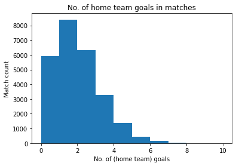

```python
#display(df_m.home_team_goal.value_counts())

plt.hist(data = df_m, x='home_team_goal');
plt.xlabel('No. of (home team) goals');
plt.ylabel('Match count');
plt.title('No. of home team goals in matches');
```

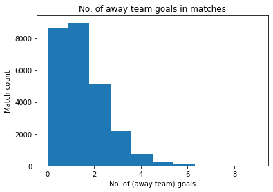

```python
#display(df_m.away_team_goal.value_counts())

plt.hist(data = df_m, x='away_team_goal');
plt.xlabel('No. of (away team) goals');
plt.ylabel('Match count');
plt.title('No. of away team goals in matches');
```

Interestingly, away team goals distribution also looks right-skewed with away team most likely scoring somwhere between 0-2 goals in a match. Looks like the data suggests that the away team has more chances of scoring either 1 or no goal at all.

For the `Player` table, let's explore there height and weight distribution.

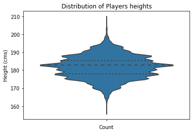

```python
#df_p.head()
sns.violinplot(data=df_p, y='height', inner="quartile");
plt.ylabel('Height (cms)');
plt.xlabel('Count')
plt.title('Distribution of Players heights');
```

From the above plot, we can quickly arrive at a conclusion that the mean height of players is ~ 184cms with trend moving towards the upper quartile. This means, probability of a soccer player being taller is high.

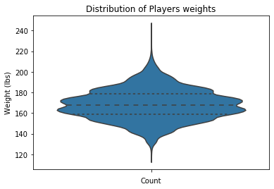

```python
sns.violinplot(data=df_p, y='weight', inner="quartile");
plt.ylabel('Weight (lbs)');
plt.xlabel('Count');
plt.title('Distribution of Players weights');
```

Unlike the heights, mean weights is slightly sliding towards a lower quartile. This is indicative of the fact that soccer players are hardly over-weight. The mean weight of a player is around 170 pounds.

#### Bivariant analysis:

```python
df_c['match_count'] = df_c['id']
df_c['match_count'] = df_c.apply(lambda x: match_count_dict[x['match_count']], axis=1)
df_c.replace({'England':'United Kingdom'}, inplace=True)
df_c
```

|  | id | name | match_count |
| --- | --- | --- | --- |
| 0 | 1 | Belgium | 1728 |
| 1 | 1729 | United Kingdom | 3040 |
| 2 | 4769 | France | 3040 |
| 3 | 7809 | Germany | 2448 |
| 4 | 10257 | Italy | 3017 |
| 5 | 13274 | Netherlands | 2448 |
| 6 | 15722 | Poland | 1920 |
| 7 | 17642 | Portugal | 2052 |
| 8 | 19694 | Scotland | 1824 |
| 9 | 21518 | Spain | 3040 |
| 10 | 24558 | Switzerland | 1422 |

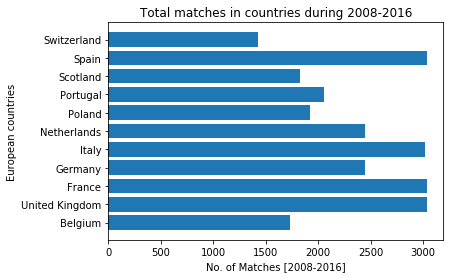

```python
plt.barh(df_c.name , df_c.match_count)
plt.xlabel('No. of Matches [2008-2016]');
plt.ylabel('European countries');
plt.title('Total matches in countries during 2008-2016');
```

During the period 2008-2016, Spain, Italy, France and England have hosted more matches than their counterparts. I am a bit intrigued to the no. of matches in Germany far lower than their counterparts. Maybe, the top 4: Spain, Italy, France and England host more matches as they generate considerably higher sponsorship revenues. Hmm...that's a question to answer. But, not for this report!

Let's now visualize the cummulative match data on a worldmap using folium. To accomplish this, we have already downloaded the necessary `world_countries.json` template from one of folium examples.

```python
import os

country_geo = os.path.join('../datasets/world-countries.json')

soccer_map_choropleth = folium.Map(location=[50.0,6.0],
                                   zoom_start=4,
                                   width='100%', height='80%')
folium.TileLayer('openstreetmap').add_to(soccer_map_choropleth)
folium.TileLayer('stamentoner').add_to(soccer_map_choropleth)

folium.Choropleth(geo_data=country_geo,
                  name='choropleth',
                  data=df_c,
                  columns=['name','match_count'],
                  key_on='feature.properties.name',
                  fill_color='YlOrRd',
                  nan_fill_color='white',
                  fill_opacity=0.45,
                  line_opacity=0.5,
                  legend_name='No. of matches [2008-2016]').add_to(soccer_map_choropleth)

folium.LayerControl().add_to(soccer_map_choropleth)
soccer_map_choropleth
```

[interactive chart not shown]

Looks like, we can correlate the data both on bar chart and folium map data. Nice!

### 2. Which player had the most penalties among all leagues from 2008 to 2016 ?

```python
df_pa.head()
```

|  | id | player_fifa_api_id | player_api_id | date | overall_rating | potential | preferred_foot | attacking_work_rate | defensive_work_rate | crossing | ... | vision | penalties | marking | standing_tackle | sliding_tackle | gk_diving | gk_handling | gk_kicking | gk_positioning | gk_reflexes |
| --- | --- | --- | --- | --- | --- | --- | --- | --- | --- | --- | --- | --- | --- | --- | --- | --- | --- | --- | --- | --- | --- |
| 0 | 1 | 218353 | 505942 | 2016-02-18 00:00:00 | 67.0 | 71.0 | right | medium | medium | 49.0 | ... | 54.0 | 48.0 | 65.0 | 69.0 | 69.0 | 6.0 | 11.0 | 10.0 | 8.0 | 8.0 |
| 1 | 2 | 218353 | 505942 | 2015-11-19 00:00:00 | 67.0 | 71.0 | right | medium | medium | 49.0 | ... | 54.0 | 48.0 | 65.0 | 69.0 | 69.0 | 6.0 | 11.0 | 10.0 | 8.0 | 8.0 |
| 2 | 3 | 218353 | 505942 | 2015-09-21 00:00:00 | 62.0 | 66.0 | right | medium | medium | 49.0 | ... | 54.0 | 48.0 | 65.0 | 66.0 | 69.0 | 6.0 | 11.0 | 10.0 | 8.0 | 8.0 |
| 3 | 4 | 218353 | 505942 | 2015-03-20 00:00:00 | 61.0 | 65.0 | right | medium | medium | 48.0 | ... | 53.0 | 47.0 | 62.0 | 63.0 | 66.0 | 5.0 | 10.0 | 9.0 | 7.0 | 7.0 |
| 4 | 5 | 218353 | 505942 | 2007-02-22 00:00:00 | 61.0 | 65.0 | right | medium | medium | 48.0 | ... | 53.0 | 47.0 | 62.0 | 63.0 | 66.0 | 5.0 | 10.0 | 9.0 | 7.0 | 7.0 |

5 rows × 42 columns

```python
max_penalties = (df_pa_penalties['penalties'] == df_pa_penalties['penalties'].max())
max_penalties_player_id = df_pa_penalties[max_penalties].player_api_id.values[0]
df_p[df_p['player_api_id'] == max_penalties_player_id]
```

|  | id | player_api_id | player_name | player_fifa_api_id | birthday | height | weight |
| --- | --- | --- | --- | --- | --- | --- | --- |
| 395 | 396 | 41269 | Alessio Cerci | 178393 | 1987-07-23 00:00:00 | 180.34 | 172 |

**Alessio Cerci** with the player_api_id of 41269 has the most no. of penalties between 2008-2016. How else are in top 10?

Here, is the list of top 10 players with most no. of penalties from 2008-2016.

```python
df_p[df_p.player_api_id.isin(df_pa_penalties.head(10).player_api_id.values)]
```

|  | id | player_api_id | player_name | player_fifa_api_id | birthday | height | weight |
| --- | --- | --- | --- | --- | --- | --- | --- |
| 140 | 141 | 47394 | Adel Taarabt | 179605 | 1989-05-24 00:00:00 | 180.34 | 172 |
| 199 | 200 | 40930 | Adrien Silva | 184826 | 1989-03-15 00:00:00 | 175.26 | 152 |
| 395 | 396 | 41269 | Alessio Cerci | 178393 | 1987-07-23 00:00:00 | 180.34 | 172 |
| 703 | 706 | 30731 | Andrea Pirlo | 7763 | 1979-05-19 00:00:00 | 177.80 | 150 |
| 892 | 895 | 27734 | Antonio Di Natale | 120274 | 1977-10-13 00:00:00 | 170.18 | 154 |
| 1860 | 1863 | 41890 | Claudio Marchisio | 173210 | 1986-01-19 00:00:00 | 180.34 | 157 |
| 6795 | 6805 | 108808 | Mario Balotelli | 186627 | 1990-08-12 00:00:00 | 187.96 | 194 |
| 7327 | 7338 | 26472 | Michael Bradley | 155887 | 1987-07-31 00:00:00 | 187.96 | 174 |
| 10187 | 10203 | 30626 | Thierry Henry | 1625 | 1977-08-17 00:00:00 | 187.96 | 183 |
| 11014 | 11030 | 25772 | Zdravko Kuzmanovic | 168650 | 1987-09-22 00:00:00 | 185.42 | 176 |

Is there a bias of being right or left handed (in scoring penalties )?

```python
df_pa.attacking_work_rate.value_counts()
```

```
medium    125070
high       42823
low         8569
None        3639
norm         348
y            106
le           104
stoc          89
Name: attacking_work_rate, dtype: int64
```

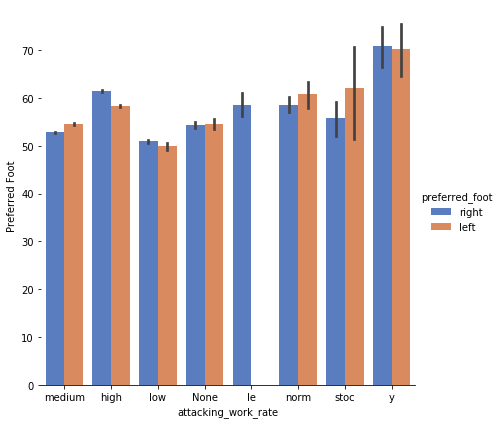

```python
g = sns.catplot(x="attacking_work_rate", y="penalties", hue="preferred_foot", data=df_pa,
                height=6, kind="bar", palette="muted")
g.despine(left=True)
g.set_ylabels("Preferred Foot");
```

Looks like preferred foot either right or left not much significant influence on penalties being score.

## References

1. [Soccer Database from Kaggle](https://d17h27t6h515a5.cloudfront.net/topher/2017/November/5a0a4cad_database/database.sqlite)